# R 초급

# 1. 데이터 읽기

- 작업디렉토리 설정 : getwd() setwd(“G:\etc\R”)
- 작업디렉토리 하위에 폴더 생성 : if(!file.exists(“data”)){ dir.create(“data”) }
- JAVA 환경변수 설정 : Sys.setenv(JAVA_HOME=‘C:\Program Files\Java\jre8’) options(java.parameters = “-Xmx8000m”)
- download.file : mode 속성 r(read),w(writing),a(appending), rb,wb,ad(binary mode, Windows) : 다운 받을 경우 파일일 깨지는 경우가 있다(xlsx 등). mode=wb로 해야 정상적으로 데이터를 다운 받을 수 있다.

## 1. 데이터 다운로드 및 읽기

### 1. csv(데이터 다운로드, 읽기)

```r
#데이터 다운로드
fileUrl <-"https://data.baltimorecity.gov/api/views/dz54-2aru/rows.csv?accessType=DOWNLOAD"
download.file(fileUrl, destfile = "data/cameras.csv") # 맥 설정(https일 경우:method="curl" 속성 추가 )
list.files("./data") # 작업디렉토리/data 에 파일 리스트 검색
```

```
## [1] "cameras.csv"     "cameras.xlsx"    "foo.txt"         "restaurants.csv"
## [5] "reviews.csv"     "solutions.csv"
```

```r
# read.table로 읽을 경우( sep= ","으로 구분하고 header 컬럼 표시 속성으로 정의)
cameraData <- read.table("data/cameras.csv", sep =",", header=TRUE) #추가 속성(quote, na.strings, nrows, skip)
head(cameraData)
```

```
##                          address direction      street  crossStreet
## 1       S CATON AVE & BENSON AVE       N/B   Caton Ave   Benson Ave
## 2       S CATON AVE & BENSON AVE       S/B   Caton Ave   Benson Ave
## 3 WILKENS AVE & PINE HEIGHTS AVE       E/B Wilkens Ave Pine Heights
## 4        THE ALAMEDA & E 33RD ST       S/B The Alameda      33rd St
## 5        E 33RD ST & THE ALAMEDA       E/B      E 33rd  The Alameda
## 6        ERDMAN AVE & N MACON ST       E/B      Erdman     Macon St
##                 intersection                      Location.1
## 1     Caton Ave & Benson Ave (39.2693779962, -76.6688185297)
## 2     Caton Ave & Benson Ave (39.2693157898, -76.6689698176)
## 3 Wilkens Ave & Pine Heights  (39.2720252302, -76.676960806)
## 4     The Alameda  & 33rd St (39.3285013141, -76.5953545714)
## 5      E 33rd  & The Alameda (39.3283410623, -76.5953594625)
## 6         Erdman  & Macon St (39.3068045671, -76.5593167803)
```

```r
#read.csv로 읽을 경우(, 컬럼 표시 자동 적용)
cameraData <- read.csv("data/cameras.csv")
#head(cameraData)
```

### 2. xlsx(데이터 다운로드, 읽기)

```r
#fileUrl <-"https://data.baltimorecity.gov/api/views/dz54-2aru/rows.xlsx?accessType=DOWNLOAD"
#download.file(fileUrl, destfile = "data/cameras.xlsx", , mode="wb")
#install.packages("xlsx")
#library(xlsx)
#cameraData <- read.xlsx("data/cameras.xlsx", sheetIndex=1, header=TRUE)
#head(cameraData)

#colIndex <- 2:3
#rowIndex <- 1:4
#cameraDataSubset <- read.xlsx("data/cameras.xlsx", sheetIndex=1,                              colIndex=colIndex, rowIndex=rowIndex)
#cameraDataSubset
```

### 4. Web페이지 읽기

```r
con = url("http://scholar.google.com/citations?user=HI-I6C0AAAAJ&hl=en")
htmlCode = readLines(con)
close(con)
#head(htmlCode)

library(XML)
url <- ("http://scholar.google.com/citations?user=HI-I6C0AAAAJ&hl=en")
html <- htmlTreeParse(url, useInternalNodes=T)
xpathSApply(html, "//title", xmlValue)
```

```
## [1] "Jeff Leek - Google Scholar Citations"
```

```r
xpathSApply(html, "//td[@id='col-citedby']", xmlValue)
```

```
## list()
```

### 5. Web페이지 xml 추출(데이터 다운로드, 읽기)

```r
fileUrl <- "http://espn.go.com/nfl/team/_/name/bal/baltimore-ravens"
doc <- htmlTreeParse(fileUrl, useInternal=TRUE)
#scores <- xpathSApply(doc, "//li[@class='score']", xmlValue)
#teams <- xpathSApply(doc, "//li[@class='team-name']", xmlValue)
#scores
#teams
```

### 6. JSON(데이터 다운로드, 읽기)

##### 참고 : http://www.r-bloggers.com/new-package-jsonlite-a-smarter-json-encoderdecoder/

```r
#install.packages("jsonlite")
#library(jsonlite)
#jsonData <- fromJSON("https://data.baltimorecity.gov/resource/8gms-s9we.json")
#names(jsonData)
#names(jsonData$owner)
#jsonData$owner$login
#myjson <- toJSON(iris, pretty=TRUE)
#cat(myjson)
#iris2 <- fromJSON(myjson)
#head(iris2)
```

### 7. Web페이지 일기 httr package(web Scraping)

#### 참고 : http://cran.r-project.org/web/packages/httr/httr.pdf

#### http://www.r-bloggers.com/?s=Web+Scraping

```r
library(httr);
library(XML)
html2 = GET(url)
content2 <- content(html2, as = "text") # http 텍스트 형태로 추출.
parsedHtml <- htmlParse(content2, asText = TRUE) # 텍스트를 분석하여 html 형식 변환
xpathSApply(parsedHtml, "//title", xmlValue)
```

```
## [1] "Jeff Leek - Google Scholar Citations"
```

```r
pg1 <- GET("http://httpbin.org/basic-auth/user/passwd") # 사용자 이름/비밀번호 필요할 경우. 인증이 안됨
pg1
```

```
## Response [http://httpbin.org/basic-auth/user/passwd]
##   Date: 2017-02-19 12:48
##   Status: 401
##   Content-Type: <unknown>
## <EMPTY BODY>
```

```r
pg2 <- GET("http://httpbin.org/basic-auth/user/passwd", # 사용자 이름 패드워드 입력
          authenticate("user", "passwd"))
pg2
```

```
## Response [http://httpbin.org/basic-auth/user/passwd]
##   Date: 2017-02-19 12:48
##   Status: 200
##   Content-Type: application/json
##   Size: 47 B
## {
##   "authenticated": true,
##   "user": "user"
## }
```

```r
names(pg2)
```

```
##  [1] "url"         "status_code" "headers"     "all_headers" "cookies"
##  [6] "content"     "date"        "times"       "request"     "handle"
```

```r
google <- handle("http://google.com")
pg1 = GET(handle=google, path="/")
pg2 = GET(handle=google, path="search")
```

## 2.DBMS 읽기

### 1. MySQL 읽기(R 3.1.0 버전에서 설치가 안됨: 수동 설치해야 함.)

install.packages(“RMySQL”) library(RMySQL) # 안돼

## 3. HDF5(대용량 데이터 저장하는 패키지) 읽기

#### 참고 : http://www.bioconductor.org/packages/release/bioc/vignettes/rhdf5/inst/doc/rhdf5.pdf

## 4. API 읽기

### 1.트위터 API

- 참고 : 개발 계정 생성 :https://apps.twitter.com/
- 참고 : 트위처API : https://dev.twitter.com/docs/api/1.1
- https://dev.twitter.com/docs/api/1/get/blocks/blocking
- https://dev.twitter.com/docs/api/1.1/get/statuses/home_timeline

```r
#myapp = oauth_app("twitter",
#                  key = "ObWsGlJXn8LhgzreCG7X1vxEZ",
#                  secret ="Swg26inPts65HQ5H0xD1YgS3sE7ttUuPfqOTzLkoBDHxk7gjRc")
#sig = sign_oauth1.0(myapp,
#                    token = "78240667-8P33MWCjyJsHDKbZzprUuSqKrSep47Jdo9tZijIHY",
#                    token_secret = "SttYunrEE70e6VbeYxRh9KP3pmYWjpsBYRpeHyejbJJC3",
#                    )

#homeTL = GET("https://api.twitter.com/1.1/statuses/home_timeline.json", sig)
#json1 = content(homeTL)
#json2 = jsonlite::fromJSON(toJSON(json1))
#json2[1,1:4]
```

## 5. 기타 소스 읽기

- 참고 : http://cran.r-project.org/web/packages/foreign/foreign.pdf
- read.arff(Weka) ; read.dta(Stats); read.mtp(Minitab);
- read.octave(Octave); read.spss(SPSS); read.xport(SAS)
- RPostresSQL
- https://code.google.com/p/rpostgresql/ ,
- http://cran.r-project.org/web/packages/RPostgreSQL/RPostgreSQL.pdf ####RODBC
- http://cran.r-project.org/web/packages/RODBC/vignettes/RODBC.pdf
- http://cran.r-project.org/web/packages/RODBC/RODBC.pdf ####RMongo
- http://cran.r-project.org/web/packages/RMongo/RMongo.pdf
- http://www.r-bloggers.com/r-and-mongodb/
- Reading images(jpeg,readbitmap,png,EBImage(Bioconductor))
- Reading GIS Data(rdgal,rgeos, raster)
- Reading music data(tuneR, seewave)

# 2. 데이터 변경

#### 참고 : http://www.biostat.jhsph.edu/~ajaffe/lec_winterR/Lecture%202.pdf

```r
X <- data.frame("var1"=sample(1:5), "var2"=sample(6:10), "var3"=sample(11:15))
X <- X[sample(1:5),]; X$var2[c(1,3)]=NA
```

## 1. Sorting And Ordering

```r
sort(X$var1)
```

```
## [1] 1 2 3 4 5
```

```r
sort(X$var1, decreasing=TRUE)
```

```
## [1] 5 4 3 2 1
```

```r
sort(X$var2, na.last=TRUE) # NA값은 마지막으로 정력
```

```
## [1]  6  8 10 NA NA
```

```r
# Ordering
X[order(X$var1),]
```

```
##   var1 var2 var3
## 2    1    8   12
## 4    2   10   11
## 3    3   NA   14
## 1    4    6   13
## 5    5   NA   15
```

```r
X[order(X$var1, X$var3),]
```

```
##   var1 var2 var3
## 2    1    8   12
## 4    2   10   11
## 3    3   NA   14
## 1    4    6   13
## 5    5   NA   15
```

## 2. 데이터 요약 및 구조 변경

```r
#데이터 요약(Summarizing Data)
fileUrl <-"https://data.baltimorecity.gov/api/views/k5ry-ef3g/rows.csv?accessType=DOWNLOAD"
download.file(fileUrl, destfile="data/restaurants.csv")
restData <- read.csv("data/restaurants.csv")
head(restData, n=3) # 첫 3행
```

```
##    name zipCode neighborhood councilDistrict policeDistrict
## 1   410   21206    Frankford               2   NORTHEASTERN
## 2  1919   21231  Fells Point               1   SOUTHEASTERN
## 3 SAUTE   21224       Canton               1   SOUTHEASTERN
##                          Location.1
## 1 4509 BELAIR ROAD\nBaltimore, MD\n
## 2    1919 FLEET ST\nBaltimore, MD\n
## 3   2844 HUDSON ST\nBaltimore, MD\n
```

```r
tail(restData, n=3) # 마지막 3행
```

```
##              name zipCode  neighborhood councilDistrict policeDistrict
## 1325 ZINK'S CAF혨   21213 Belair-Edison              13   NORTHEASTERN
## 1326 ZISSIMOS BAR   21211       Hampden               7       NORTHERN
## 1327       ZORBAS   21224     Greektown               2   SOUTHEASTERN
##                              Location.1
## 1325 3300 LAWNVIEW AVE\nBaltimore, MD\n
## 1326      1023 36TH ST\nBaltimore, MD\n
## 1327  4710 EASTERN Ave\nBaltimore, MD\n
```

```r
summary(restData)
```

```
##                            name         zipCode             neighborhood
##  MCDONALD'S                  :   8   Min.   :-21226   Downtown    :128
##  POPEYES FAMOUS FRIED CHICKEN:   7   1st Qu.: 21202   Fells Point : 91
##  SUBWAY                      :   6   Median : 21218   Inner Harbor: 89
##  KENTUCKY FRIED CHICKEN      :   5   Mean   : 21185   Canton      : 81
##  BURGER KING                 :   4   3rd Qu.: 21226   Federal Hill: 42
##  DUNKIN DONUTS               :   4   Max.   : 21287   Mount Vernon: 33
##  (Other)                     :1293                    (Other)     :863
##  councilDistrict       policeDistrict
##  Min.   : 1.000   SOUTHEASTERN:385
##  1st Qu.: 2.000   CENTRAL     :288
##  Median : 9.000   SOUTHERN    :213
##  Mean   : 7.191   NORTHERN    :157
##  3rd Qu.:11.000   NORTHEASTERN: 72
##  Max.   :14.000   EASTERN     : 67
##                   (Other)     :145
##                           Location.1
##  1101 RUSSELL ST\nBaltimore, MD\n:   9
##  201 PRATT ST\nBaltimore, MD\n   :   8
##  2400 BOSTON ST\nBaltimore, MD\n :   8
##  300 LIGHT ST\nBaltimore, MD\n   :   5
##  300 CHARLES ST\nBaltimore, MD\n :   4
##  301 LIGHT ST\nBaltimore, MD\n   :   4
##  (Other)                         :1289
```

```r
str(restData)
```

```
## 'data.frame':    1327 obs. of  6 variables:
##  $ name           : Factor w/ 1277 levels "courthouse east caf\xe2\u0080\x9a'",..: 12 4 993 2 3 5 6 7 10 11 ...
##  $ zipCode        : int  21206 21231 21224 21211 21223 21218 21205 21211 21205 21231 ...
##  $ neighborhood   : Factor w/ 173 levels "Abell","Arlington",..: 53 52 18 66 104 33 98 133 98 157 ...
##  $ councilDistrict: int  2 1 1 14 9 14 13 7 13 1 ...
##  $ policeDistrict : Factor w/ 9 levels "CENTRAL","EASTERN",..: 3 6 6 4 8 3 6 4 6 6 ...
##  $ Location.1     : Factor w/ 1210 levels "1 BIDDLE ST\nBaltimore, MD\n",..: 835 334 554 755 492 537 505 530 507 569 ...
```

```r
quantile(restData$councilDistrict, na.rm=TRUE)
```

```
##   0%  25%  50%  75% 100%
##    1    2    9   11   14
```

```r
quantile(restData$councilDistrict, probs=c(0.5,0.75,0.9))
```

```
## 50% 75% 90%
##   9  11  12
```

```r
table(restData$zipCode, useNA="ifany") #ZipCode의 갯수(NA일 경우 추가하라)
```

```
##
## -21226  21201  21202  21205  21206  21207  21208  21209  21210  21211
##      1    136    201     27     30      4      1      8     23     41
##  21212  21213  21214  21215  21216  21217  21218  21220  21222  21223
##     28     31     17     54     10     32     69      1      7     56
##  21224  21225  21226  21227  21229  21230  21231  21234  21237  21239
##    199     19     18      4     13    156    127      7      1      3
##  21251  21287
##      2      1
```

```r
table(restData$councilDistrict, restData$zipCode) #지구별, 코드
```

```
##
##      -21226 21201 21202 21205 21206 21207 21208 21209 21210 21211 21212
##   1       0     0    37     0     0     0     0     0     0     0     0
##   2       0     0     0     3    27     0     0     0     0     0     0
##   3       0     0     0     0     0     0     0     0     0     0     0
##   4       0     0     0     0     0     0     0     0     0     0    27
##   5       0     0     0     0     0     3     0     6     0     0     0
##   6       0     0     0     0     0     0     0     1    19     0     0
##   7       0     0     0     0     0     0     0     1     0    27     0
##   8       0     0     0     0     0     1     0     0     0     0     0
##   9       0     1     0     0     0     0     0     0     0     0     0
##   10      1     0     1     0     0     0     0     0     0     0     0
##   11      0   115   139     0     0     0     1     0     0     0     1
##   12      0    20    24     4     0     0     0     0     0     0     0
##   13      0     0     0    20     3     0     0     0     0     0     0
```

[output cut: 33 more lines]

```r
#데이터 점검 Summary
table(restData$zipCode %in% c("21212")) #해당 zipCode의 포함되는 수 표시
```

```
##
## FALSE  TRUE
##  1299    28
```

```r
table(restData$zipCode %in% c("21212","21213"))
```

```
##
## FALSE  TRUE
##  1268    59
```

```r
restData[restData$zipCode %in% c("21212","21213"),]
```

```
##                                      name zipCode
## 29                      BAY ATLANTIC CLUB   21212
## 39                            BERMUDA BAR   21213
## 92                              ATWATER'S   21212
## 111            BALTIMORE ESTONIAN SOCIETY   21213
## 187                              CAFE ZEN   21212
## 220                   CERIELLO FINE FOODS   21212
## 266    CLIFTON PARK GOLF COURSE SNACK BAR   21213
## 276                CLUB HOUSE BAR & GRILL   21213
## 289                 CLUBHOUSE BAR & GRILL   21213
## 291                           COCKY LOU'S   21213
## 362       DREAM TAVERN, CARRIBEAN  U.S.A.   21213
## 373                         DUNKIN DONUTS   21212
## 383        EASTSIDE  SPORTS  SOCIAL  CLUB   21213
## 417                      FIELDS OLD TRAIL   21212
```

[output cut: 165 more lines]

```r
restData$zipWrong = ifelse(restData$zipCode <0, TRUE, FALSE) #우편번호가 0보다 작으면 TRUE
table(restData$zipWrong, restData$zipCode <0)
```

```
##
##         FALSE TRUE
##   FALSE  1326    0
##   TRUE      0    1
```

```r
#4분위수를 해당하는 값에 갯수 파악 Summary
restData$zipGroups = cut(restData$zipCode, breaks=quantile(restData$zipCode)) #양적함수? cut?
table(restData$zipGroups)
```

```
##
## (-2.123e+04,2.12e+04]  (2.12e+04,2.122e+04] (2.122e+04,2.123e+04]
##                   337                   375                   282
## (2.123e+04,2.129e+04]
##                   332
```

```r
#결과:(-2.123e+04,2.12e+04]  (2.12e+04,2.122e+04] (2.122e+04,2.123e+04] (2.123e+04,2.129e+04]
#       0~25%                   25~50%                50~75%                   75~100%
table(restData$zipGroups, restData$zipCode)
```

```
##
##                         -21226 21201 21202 21205 21206 21207 21208 21209
##   (-2.123e+04,2.12e+04]      0   136   201     0     0     0     0     0
##   (2.12e+04,2.122e+04]       0     0     0    27    30     4     1     8
##   (2.122e+04,2.123e+04]      0     0     0     0     0     0     0     0
##   (2.123e+04,2.129e+04]      0     0     0     0     0     0     0     0
##
##                         21210 21211 21212 21213 21214 21215 21216 21217
##   (-2.123e+04,2.12e+04]     0     0     0     0     0     0     0     0
##   (2.12e+04,2.122e+04]     23    41    28    31    17    54    10    32
##   (2.122e+04,2.123e+04]     0     0     0     0     0     0     0     0
##   (2.123e+04,2.129e+04]     0     0     0     0     0     0     0     0
##
##                         21218 21220 21222 21223 21224 21225 21226 21227
##   (-2.123e+04,2.12e+04]     0     0     0     0     0     0     0     0
##   (2.12e+04,2.122e+04]     69     0     0     0     0     0     0     0
##   (2.122e+04,2.123e+04]     0     1     7    56   199    19     0     0
##   (2.123e+04,2.129e+04]     0     0     0     0     0     0    18     4
##
##                         21229 21230 21231 21234 21237 21239 21251 21287
##   (-2.123e+04,2.12e+04]     0     0     0     0     0     0     0     0
##   (2.12e+04,2.122e+04]      0     0     0     0     0     0     0     0
##   (2.122e+04,2.123e+04]     0     0     0     0     0     0     0     0
##   (2.123e+04,2.129e+04]    13   156   127     7     1     3     2     1
```

```r
##Cress tabs(변수를 행,열로 크로스 하여 보여준다)
data(UCBAdmissions)
DF = as.data.frame(UCBAdmissions)
summary(DF)
```

```
##       Admit       Gender   Dept       Freq
##  Admitted:12   Male  :12   A:4   Min.   :  8.0
##  Rejected:12   Female:12   B:4   1st Qu.: 80.0
##                            C:4   Median :170.0
##                            D:4   Mean   :188.6
##                            E:4   3rd Qu.:302.5
##                            F:4   Max.   :512.0
```

```r
xt <- xtabs(Freq ~ Gender + Admit, data=DF)
xt
```

```
##         Admit
## Gender   Admitted Rejected
##   Male       1198     1493
##   Female      557     1278
```

```r
##Flat tables(데이터를 평면으로 보여준다_)
warpbreaks$replicate <- rep(1:9, len = 54)
xt = xtabs(breaks ~ . , data=warpbreaks )
xt
```

```
## , , replicate = 1
##
##     tension
## wool  L  M  H
##    A 26 18 36
##    B 27 42 20
##
## , , replicate = 2
##
##     tension
## wool  L  M  H
##    A 30 21 21
##    B 14 26 21
##
## , , replicate = 3
##
##     tension
## wool  L  M  H
##    A 54 29 24
##    B 29 19 24
##
## , , replicate = 4
##
##     tension
## wool  L  M  H
##    A 25 17 18
##    B 19 16 17
##
## , , replicate = 5
##
##     tension
## wool  L  M  H
##    A 70 12 10
##    B 29 39 13
##
## , , replicate = 6
##
##     tension
## wool  L  M  H
##    A 52 18 43
##    B 31 28 15
##
## , , replicate = 7
##
##     tension
## wool  L  M  H
##    A 51 35 28
##    B 41 21 15
##
## , , replicate = 8
##
##     tension
## wool  L  M  H
##    A 26 30 15
##    B 20 39 16
##
## , , replicate = 9
##
##     tension
## wool  L  M  H
##    A 67 36 26
##    B 44 29 28
```

```r
ftable(xt) # 데이터를 보기 힘들기 때문에, 평면으로 보여준다.
```

```
##              replicate  1  2  3  4  5  6  7  8  9
## wool tension
## A    L                 26 30 54 25 70 52 51 26 67
##      M                 18 21 29 17 12 18 35 30 36
##      H                 36 21 24 18 10 43 28 15 26
## B    L                 27 14 29 19 29 31 41 20 44
##      M                 42 26 19 16 39 28 21 39 29
##      H                 20 21 24 17 13 15 15 16 28
```

## 3. 결측 값 및 데이터 점검 및 기타

```r
#결측 값
sum(is.na(restData$councilDistrict)) # 0,1 반환
```

```
## [1] 0
```

```r
any(is.na(restData$councilDistrict)) # TRUE, FALSE 반환(1개라도)
```

```
## [1] FALSE
```

```r
all(restData$zipCode > 0) # 모든것 TRUE,FALSE
```

```
## [1] FALSE
```

```r
#결측 값 Column summary
colSums(is.na(restData))
```

```
##            name         zipCode    neighborhood councilDistrict
##               0               0               0               0
##  policeDistrict      Location.1        zipWrong       zipGroups
##               0               0               0               1
```

```r
all(colSums(is.na(restData))==0)
```

```
## [1] FALSE
```

```r
#논리 비교
X[(X$var1 <=3 & X$var3 > 11),]
```

```
##   var1 var2 var3
## 3    3   NA   14
## 2    1    8   12
```

```r
X[(X$var1 <=3 | X$var3 > 15),]
```

```
##   var1 var2 var3
## 3    3   NA   14
## 2    1    8   12
## 4    2   10   11
```

```r
# 변수 추가
X$var4 <- rnorm(5)
Y <- cbind(X, rnorm(5))

##Size of a data set(데이터셋 데이터 크기 확인)
fakeData = rnorm(1e5)
object.size(fakeData)
```

```
## 800040 bytes
```

```r
print(object.size(fakeData), units="Mb")
```

```
## 0.8 Mb
```

## 4. 데이터 재 형성

#### 참고 : http://www.slideshare.net/jeffreybreen/reshaping-data-in-r

```r
#install.packages("reshape")
library(reshape)

#month,day 변수 기준으로  모든 변수의 variable이 값으로 변수의 값은 Value로 변경.(결측값 제거 : na.rm=TRUE)
aqm <- melt(airquality, id=c("Month", "Day"), na.rm=TRUE)

# y축 day, x축 month, dimension과 measure에 해당되는 변수(variable)값을 표시한다.
a <- cast(aqm, Day ~ Month ~ variable)

# y축 month, x축 variable, 에 대한 월별 각 variable에 평균값 산출
b <- cast(aqm, Month ~ variable, mean)

# y축 month, x축 variable, 에 대한 월별 각 variable을 (항목[Member])분리해 평균값 표시
c <- cast(aqm, Month ~ . |variable, mean)

# margins 행("grand_row"), 열("grand_col")에 대한 소계 산출
d <- cast(aqm, Month ~ variable, mean, margins=c("grand_row","grand_col"))

# 특정변수만 처리하고자 하는 경우 서브세트 기능을 이용해 ozones에 대한 변수만 처리
e <- cast(aqm, Day ~ Month, mean, subset=variable=="Ozone")

# min, max를 동시에 표시해주는 range : min은 _X1, max는 _X2라는 suffix를 붙여준다.
f <- cast(aqm, Month ~ variable, range)
```

#### plyr

plyr apply(ddply)함수에 기반해 데이터와 출력변수를 동시에 배열로 치환하여 처리하는 패키지 이다. 예를들어 ddply함수는 데이터프레임 데이터를 가공해 데이터프레임으로 돌려준다

난수데이터 생성 year변수에 2000,2001,2002년 데이터를 만들고, count 변수에 난수를 생성하는 함수round 를 이용하여 0에서 20사이의 숫자 중 9개를 저장한다. runif(생성할 난수의 갯수, 최솟값, 최대값) runif(9,0,20)

- set.seed 함수는 R에서 난수를 생성할 때 일정하게 고정시켜주는 역할을 한다.
- 즉 난수가, 1,6,9 가 발생했다면, 반복적으로 1,6,9가 생성되가 만들어 주는 역할을 한다.
- ()숫자를 변경하면 다른 케이스의 결과가 나오지만, 케이스마다 난수의 값은 같다.

```r
#install.packages("plyr")
library(plyr)
set.seed(1)
d <- data.frame(year=rep(2000:2002, each=6), count=round(runif(9, 0, 20)))
print(d)
```

```
##    year count
## 1  2000     5
## 2  2000     7
## 3  2000    11
## 4  2000    18
## 5  2000     4
## 6  2000    18
## 7  2001    19
## 8  2001    13
## 9  2001    13
## 10 2001     5
## 11 2001     7
## 12 2001    11
## 13 2002    18
## 14 2002     4
## 15 2002    18
## 16 2002    19
## 17 2002    13
## 18 2002    13
```

```r
#year를 함수로 입력받고 year의 mean과 sd를 구해 각각 저장한 다음 cv를 구한다.
#결과를 year별로 리터하면데 데이터플레임을 생성하다. for loop도 없고 간단한 예제다.
ddply(d, "year", function(x) {
  mean.count <-mean(x$count)
  sd.count <- sd(x$count)
  cv <- sd.count/mean.count
  data.frame(mean.count, sd.count, cv.count = cv)
})
```

```
##   year mean.count sd.count  cv.count
## 1 2000   10.50000 6.284903 0.5985621
## 2 2001   11.33333 4.966555 0.4382254
## 3 2002   14.16667 5.636193 0.3978489
```

```r
# transform  d 데이터 프레임의 전체 row 표현
# summarize 변수 year의 값들이 groupping되어 distinct한 row 표현
ddply(d, "year", summarise, mean.count = mean(count))
```

```
##   year mean.count
## 1 2000   10.50000
## 2 2001   11.33333
## 3 2002   14.16667
```

```r
ddply(d, "year", transform, total.count = sum(count))
```

```
##    year count total.count
## 1  2000     5          63
## 2  2000     7          63
## 3  2000    11          63
## 4  2000    18          63
## 5  2000     4          63
## 6  2000    18          63
## 7  2001    19          68
## 8  2001    13          68
## 9  2001    13          68
## 10 2001     5          68
## 11 2001     7          68
## 12 2001    11          68
## 13 2002    18          85
## 14 2002     4          85
## 15 2002    18          85
## 16 2002    19          85
## 17 2002    13          85
## 18 2002    13          85
```

#### sqldf를 이용한 데이터 분석

- R에서는 sqldf package를 통하여 표준 sql에서 사용되는 문장을 사용할 수 있다.

```r
#install.packages("sqldf")
library(sqldf)
#sqldf 함수의 "" 안에 sql로 표현
sqldf("select * from iris limit 10")  # iris 10행(Row)수 데이터 조회 = head(iris, 10)
```

```
##    Sepal.Length Sepal.Width Petal.Length Petal.Width Species
## 1           5.1         3.5          1.4         0.2  setosa
## 2           4.9         3.0          1.4         0.2  setosa
## 3           4.7         3.2          1.3         0.2  setosa
## 4           4.6         3.1          1.5         0.2  setosa
## 5           5.0         3.6          1.4         0.2  setosa
## 6           5.4         3.9          1.7         0.4  setosa
## 7           4.6         3.4          1.4         0.3  setosa
## 8           5.0         3.4          1.5         0.2  setosa
## 9           4.4         2.9          1.4         0.2  setosa
## 10          4.9         3.1          1.5         0.1  setosa
```

```r
#like문을 조건 ''안에 표현하여 사용된다
sqldf("select count(*) from iris where Species like 'Se%'")
```

```
##   count(*)
## 1       50
```

## 5. 데이터 병합(Merging Data)

#### 참고 병합 :http://www.statmethods.net/management/merging.html

#### 참고 Join :http://en.wikipedia.org/wiki/Join_(SQL)

```r
fileUrl1 <-"https://dl.dropboxusercontent.com/u/7710864/data/reviews-apr29.csv"
fileUrl2 <-"https://dl.dropboxusercontent.com/u/7710864/data/solutions-apr29.csv"
download.file(fileUrl1, destfile = "data/reviews.csv")
download.file(fileUrl2, destfile = "data/solutions.csv")
reviews = read.csv("data/reviews.csv");
solutions <- read.csv("data/solutions.csv");
head(reviews)
```

```
##   id solution_id reviewer_id      start       stop time_left accept
## 1  1           3          27 1304095698 1304095758      1754      1
## 2  2           4          22 1304095188 1304095206      2306      1
## 3  3           5          28 1304095276 1304095320      2192      1
## 4  4           1          26 1304095267 1304095423      2089      1
## 5  5          10          29 1304095456 1304095469      2043      1
## 6  6           2          29 1304095471 1304095513      1999      1
```

```r
head(solutions)
```

```
##   id problem_id subject_id      start       stop time_left answer
## 1  1        156         29 1304095119 1304095169      2343      B
## 2  2        269         25 1304095119 1304095183      2329      C
## 3  3         34         22 1304095127 1304095146      2366      C
## 4  4         19         23 1304095127 1304095150      2362      D
## 5  5        605         26 1304095127 1304095167      2345      A
## 6  6        384         27 1304095131 1304095270      2242      C
```

```r
names(reviews)
```

```
## [1] "id"          "solution_id" "reviewer_id" "start"       "stop"
## [6] "time_left"   "accept"
```

```r
names(solutions)
```

```
## [1] "id"         "problem_id" "subject_id" "start"      "stop"
## [6] "time_left"  "answer"
```

```r
mergedData = merge(reviews, solutions, by.x="solution_id", by.y="id", all=TRUE)# x,y데이터를 병합, by.x, by.y기반으로 병합 모든 컬럼.
head(mergedData)
```

```
##   solution_id id reviewer_id    start.x     stop.x time_left.x accept
## 1           1  4          26 1304095267 1304095423        2089      1
## 2           2  6          29 1304095471 1304095513        1999      1
## 3           3  1          27 1304095698 1304095758        1754      1
## 4           4  2          22 1304095188 1304095206        2306      1
## 5           5  3          28 1304095276 1304095320        2192      1
## 6           6 16          22 1304095303 1304095471        2041      1
##   problem_id subject_id    start.y     stop.y time_left.y answer
## 1        156         29 1304095119 1304095169        2343      B
## 2        269         25 1304095119 1304095183        2329      C
## 3         34         22 1304095127 1304095146        2366      C
## 4         19         23 1304095127 1304095150        2362      D
## 5        605         26 1304095127 1304095167        2345      A
## 6        384         27 1304095131 1304095270        2242      C
```

```r
intersect(names(solutions), names(reviews)) # 교집합
```

```
## [1] "id"        "start"     "stop"      "time_left"
```

```r
margedData2 = merge(reviews, solutions, all=TRUE) # Row 병합
head(margedData2)
```

```
##   id      start       stop time_left solution_id reviewer_id accept
## 1  1 1304095119 1304095169      2343          NA          NA     NA
## 2  1 1304095698 1304095758      1754           3          27      1
## 3  2 1304095119 1304095183      2329          NA          NA     NA
## 4  2 1304095188 1304095206      2306           4          22      1
## 5  3 1304095127 1304095146      2366          NA          NA     NA
## 6  3 1304095276 1304095320      2192           5          28      1
##   problem_id subject_id answer
## 1        156         29      B
## 2         NA         NA   <NA>
## 3        269         25      C
## 4         NA         NA   <NA>
## 5         34         22      C
## 6         NA         NA   <NA>
```

```r
df1 = data.frame(id=sample(1:10), x=rnorm(10))
df2 = data.frame(id=sample(1:10), y=rnorm(10))
arrange(join(df1,df2), id) #plyr package
```

```
##    id          x           y
## 1   1  0.7635935 -0.43331032
## 2   2 -0.7990092  0.72675075
## 3   3 -0.2992151 -0.23570656
## 4   4 -0.4115108  0.04672617
## 5   5 -0.2894616  0.50360797
## 6   6 -0.8919211 -0.69095384
## 7   7  0.4356833 -0.54288826
## 8   8  0.2522234  1.08576936
## 9   9 -1.1476570 -1.28459935
## 10 10 -1.2375384 -0.64947165
```

```r
df1 = data.frame(id=sample(1:10), x=rnorm(10))
df2 = data.frame(id=sample(1:10), y=rnorm(10))
df3 = data.frame(id=sample(1:10), z=rnorm(10))
dfList = list(df1,df2,df3)
join_all(dfList)#plyr package
```

```
##    id          x           y           z
## 1   9  1.7579031 -1.26361438 -0.91206837
## 2   4  0.5607461  0.35872890  0.66413570
## 3   7 -0.4527840  0.25014132 -1.43758624
## 4   3 -0.8320433 -0.17262350  0.14377148
## 5   8 -1.1665705 -0.11582532 -0.11916876
## 6   6 -1.0655906  0.61824329  0.01915639
## 7  10 -1.5637821 -0.81496871  0.25733838
## 8   5  1.1565370 -0.94064916  1.10096910
## 9   1  0.8320471 -0.01104548 -0.64901008
## 10  2 -0.2273287 -2.22390027 -0.11775360
```

# 3. 날짜 함수

#### 참고(lubridate:library):http://www.r-statistics.com/2012/03/do-more-with-dates-and-times-in-r-with-lubridate-1-1-0/

```r
d1 = date()
class(d1)
```

```
## [1] "character"
```

```r
d2 = Sys.Date()
class(d2)
```

```
## [1] "Date"
```

```r
# %d = (0-31), %a = 월-일, %A = 월요일-일요일, %m = (00-12), %B = 1월~12월, %y =(14), %Y = (2014)
format(d2, "%a %b %d %B")
```

```
## [1] "일 2 19 2월"
```

```r
x = c("1jan1960", "2jan1960", "31mar1960", "30jul1960");
z = as.Date(x, "%d%b%Y")
z[1]-z[2]
```

```
## Time difference of NA days
```

```r
as.numeric(z[1]-z[2])
```

```
## [1] NA
```

```r
d2 <- c(seq(as.Date(d2[1]+1),as.Date(d2[1]+10),by=2))
weekdays(d2) #요일
```

```
## [1] "월요일" "수요일" "금요일" "일요일" "화요일"
```

```r
months(d2)  #월
```

```
## [1] "2월" "2월" "2월" "2월" "2월"
```

```r
julian(d2) #줄리안 데이터 1970-01-01이 시작 1이다.
```

```
## [1] 17217 17219 17221 17223 17225
## attr(,"origin")
## [1] "1970-01-01"
```

# 4. 데이터 시각화

## 1. Base Plot

#### Parameter : pch(plot symbol), lty(라인타입,솔리드,다쉬,도트), lwd(라인위스)

#### col(칼라), xlab(x레이블), ylab(y레이블), par(las, bg, mar, oma, mfrow, mfcol) global 변수

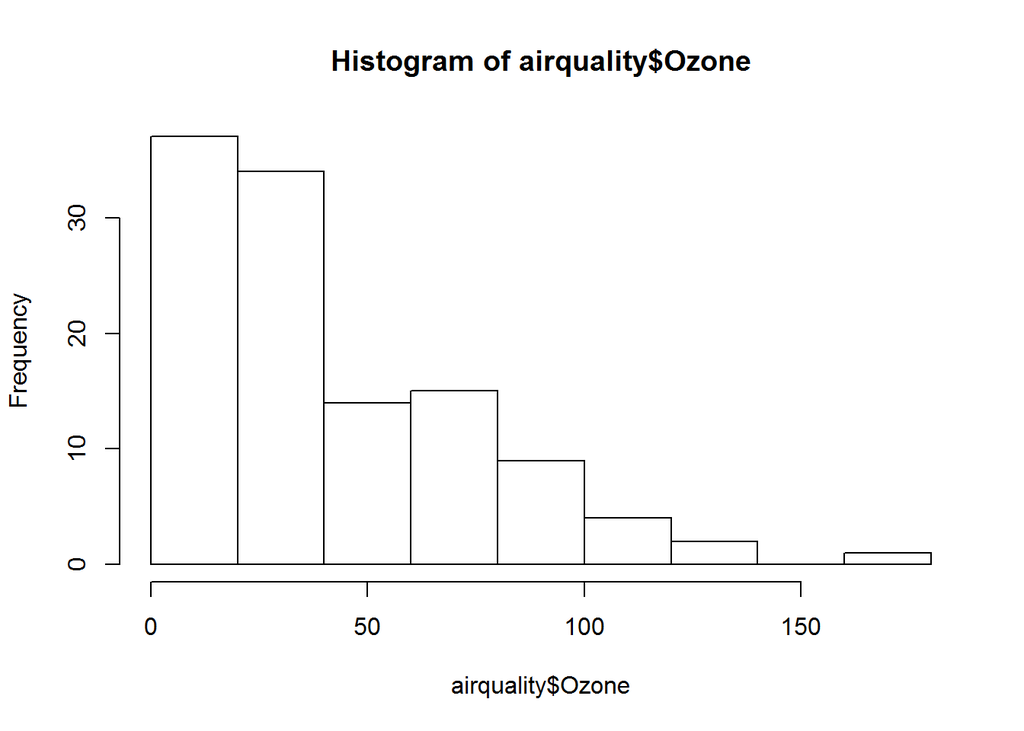

```r
hist(airquality$Ozone)
```

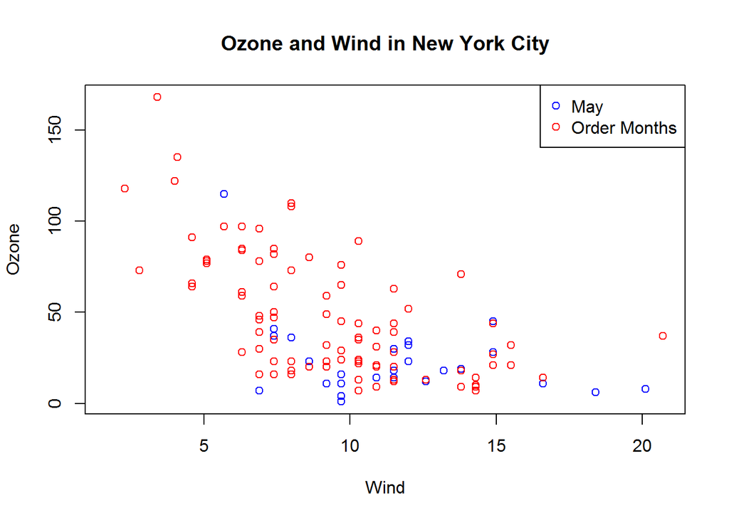

```r
with(airquality, plot(Wind, Ozone))
title(main = "Ozone and Wind in New York City") ## with(airquality, plot(Wind, Ozone, main = "Ozone and Wind in New York City"))
with(subset(airquality, Month ==5),  points(Wind, Ozone, col = "blue"))
with(subset(airquality, Month !=5),  points(Wind, Ozone, col = "red"))
legend("topright", pch =1, col = c("blue", "red"), legend = c("May", "Order Months" ))
```

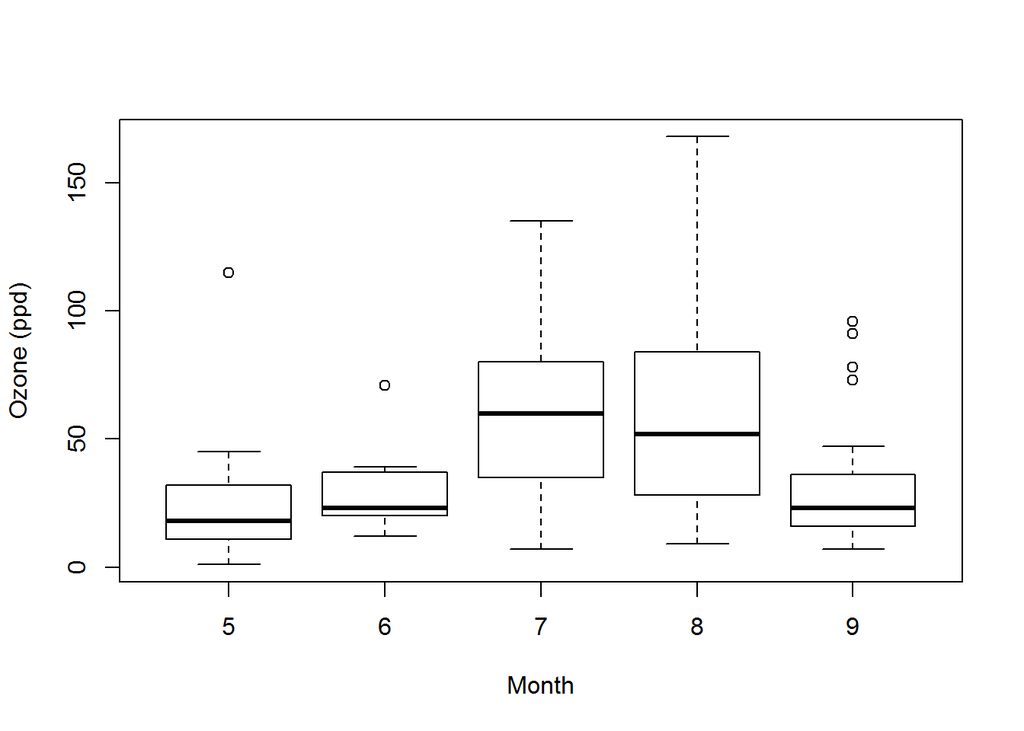

```r
airquality <- transform(airquality, Month = factor(Month))
boxplot(Ozone ~ Month, airquality, xlab = "Month", ylab = "Ozone (ppd)")
```

```r
par("lty","col","pch","bg","mar","mfrow")
```

```
## $lty
## [1] "solid"
##
## $col
## [1] "black"
##
## $pch
## [1] 1
##
## $bg
## [1] "white"
##
## $mar
## [1] 5.1 4.1 4.1 2.1
##
## $mfrow
## [1] 1 1
```

#### 회귀 라인, 선형모델

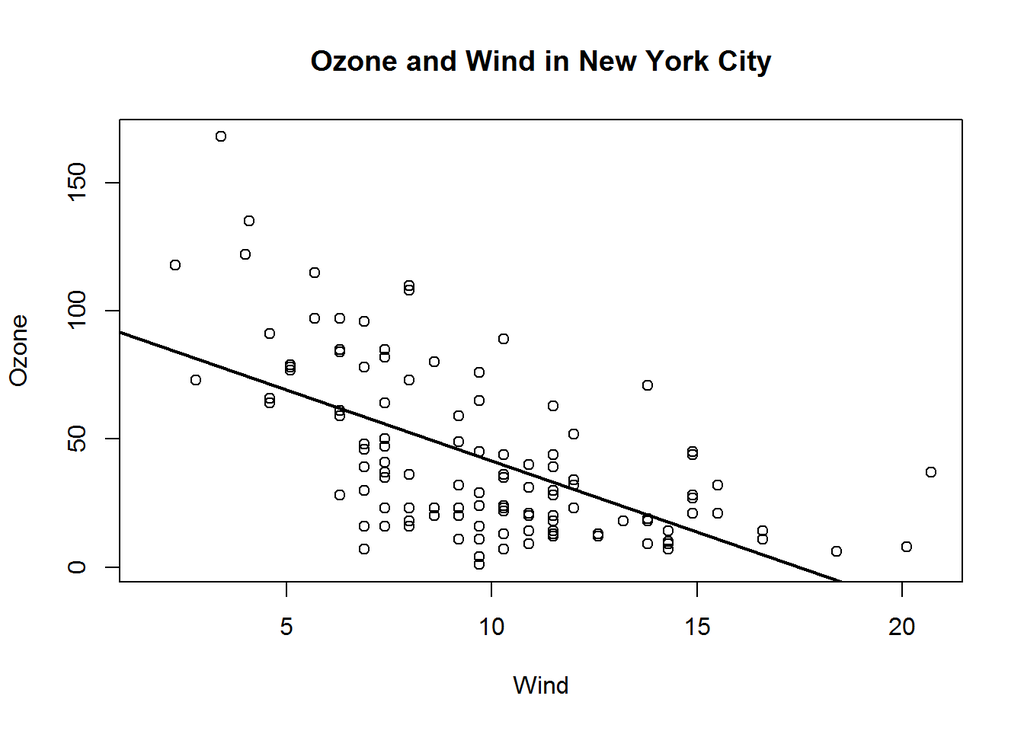

```r
with(airquality, plot(Wind, Ozone, main = "Ozone and Wind in New York City"), pch = 20)
model <- lm(Ozone ~ Wind, airquality)
abline(model, lwd =2)
```

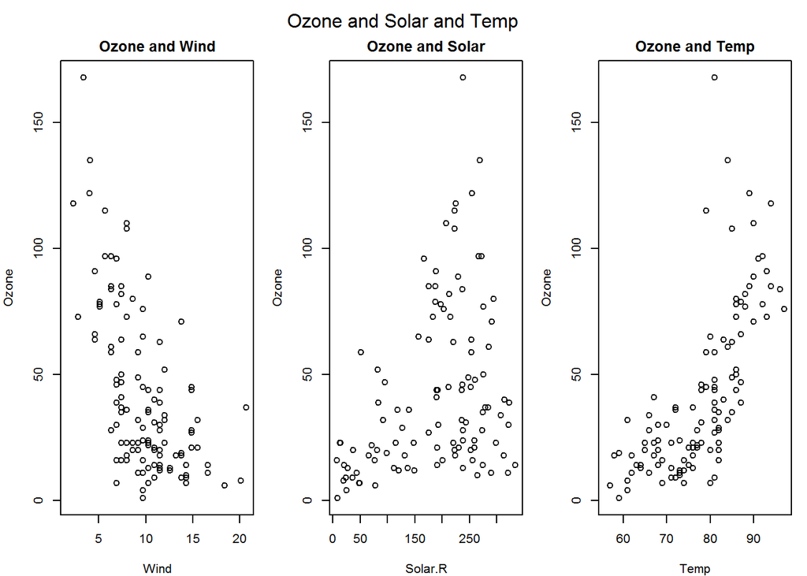

```r
#Multiple Base Plots
par(mfrow = c(1,2))
with(airquality, {
    plot(Wind, Ozone, main = "Ozone and Wind")
    plot(Solar.R, Ozone, main = "Ozone and Solar") })

par(mfrow = c(1,3), mar = c(4, 4, 2, 1), oma = c(0,0,2,0))
with(airquality, {
    plot(Wind, Ozone, main = "Ozone and Wind")
    plot(Solar.R, Ozone, main = "Ozone and Solar")
    plot(Temp, Ozone, main = "Ozone and Temp")
    mtext("Ozone and Solar and Temp",  outer =TRUE) })
```

#### 여백설정 및 차트 배열

```r
example(points)
```

```
##
## points> require(stats) # for rnorm
##
## points> plot(-4:4, -4:4, type = "n")  # setting up coord. system
```

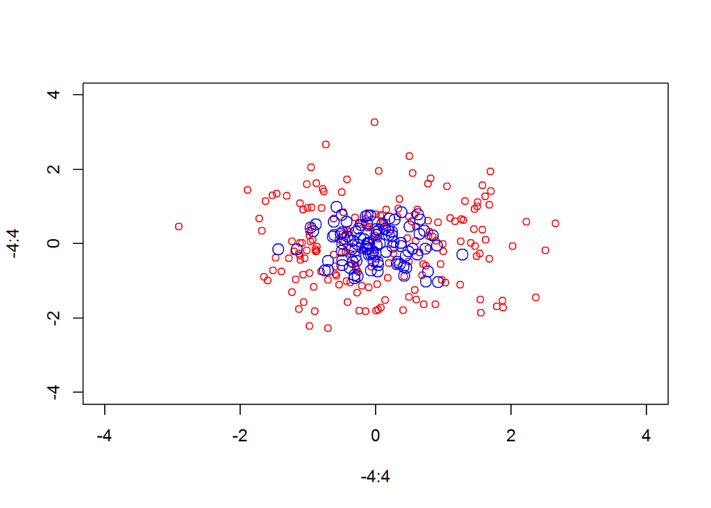

```
##
## points> points(rnorm(200), rnorm(200), col = "red")
##
## points> points(rnorm(100)/2, rnorm(100)/2, col = "blue", cex = 1.5)
##
## points> op <- par(bg = "light blue")
##
## points> x <- seq(0, 2*pi, len = 51)
##
## points> ## something "between type='b' and type='o'":
## points> plot(x, sin(x), type = "o", pch = 21, bg = par("bg"), col = "blue", cex = .6,
## points+  main = 'plot(..., type="o", pch=21, bg=par("bg"))')
```

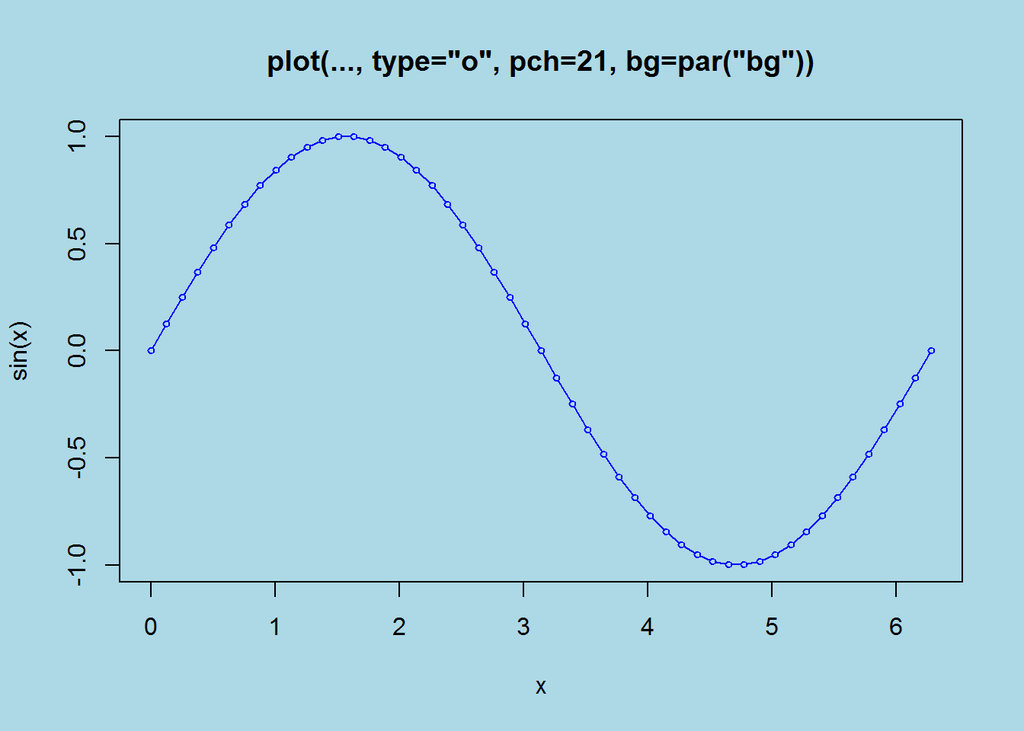

[output not shown]

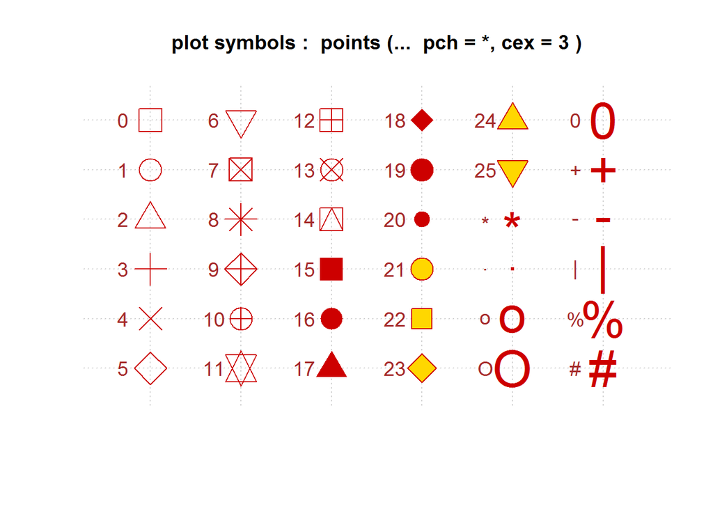

```
##
## points> pchShow(c("o","O","0"), cex = 2.5)
```

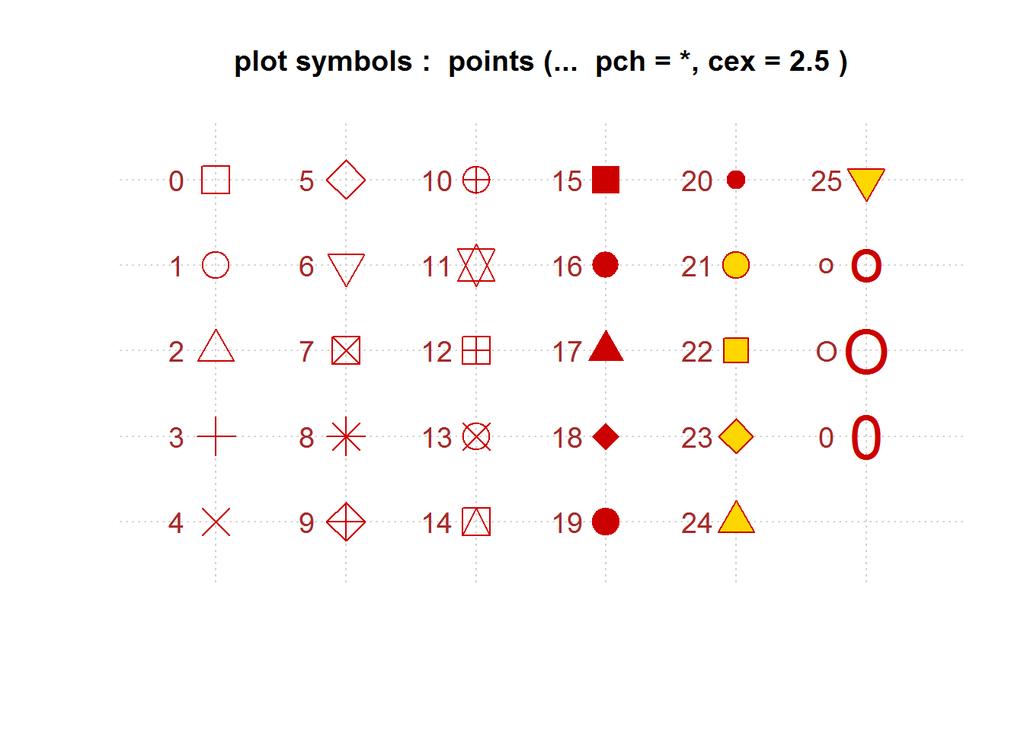

```
##
## points> pchShow(NULL, cex = 4, cextext = 0, main = NULL)
```

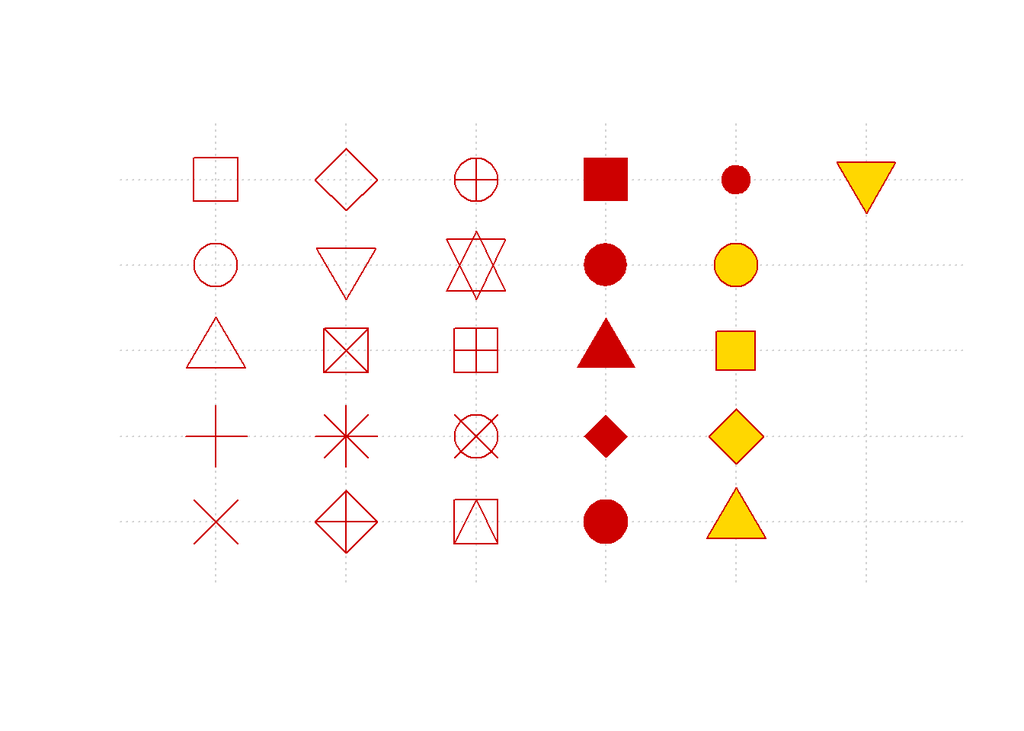

[output not shown]

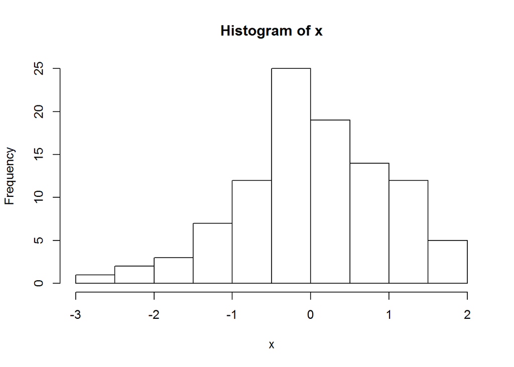

```r
x <- rnorm(100)
hist(x)
```

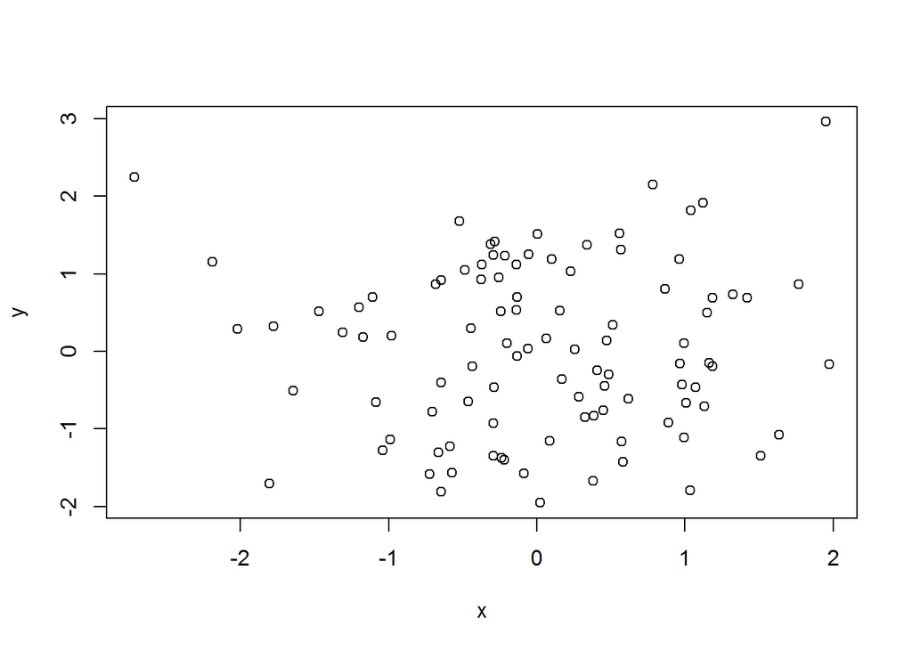

```r
y <- rnorm(100)
plot(x, y)
```

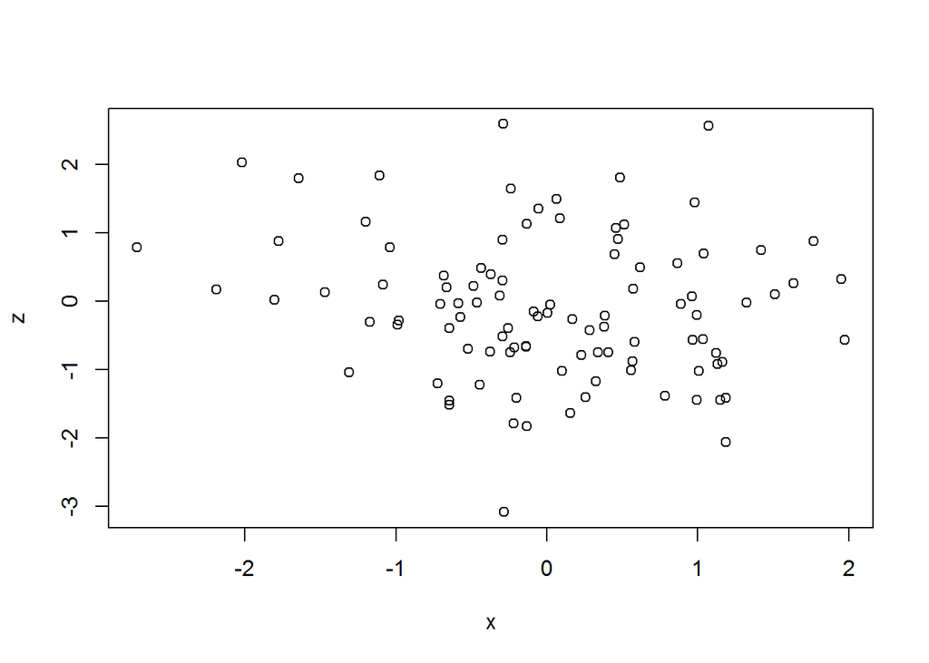

```r
z <- rnorm(100)
plot(x,z)
```

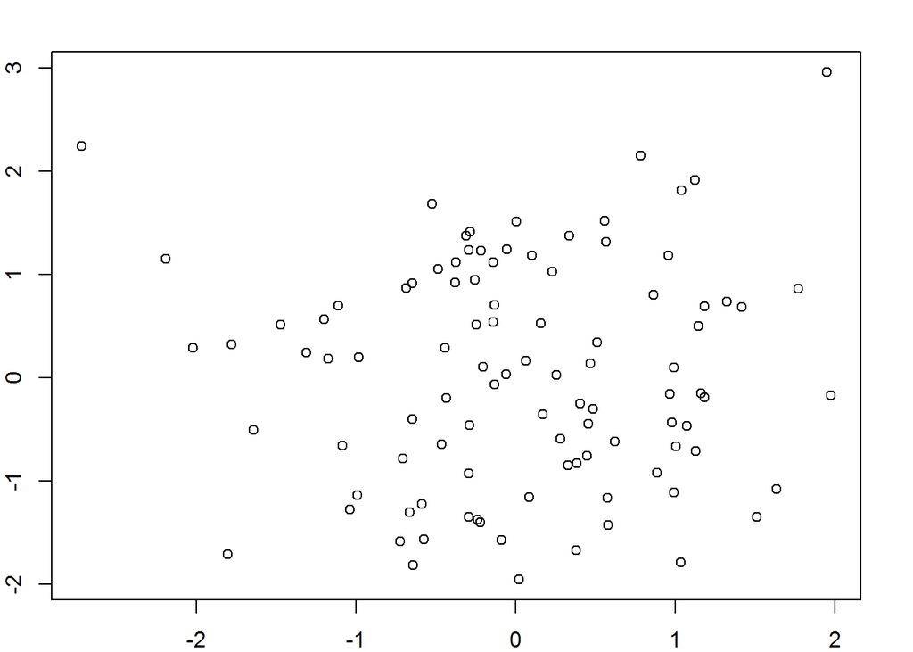

```r
par(mar = c(2,2,2,2))
plot(x,y)
```

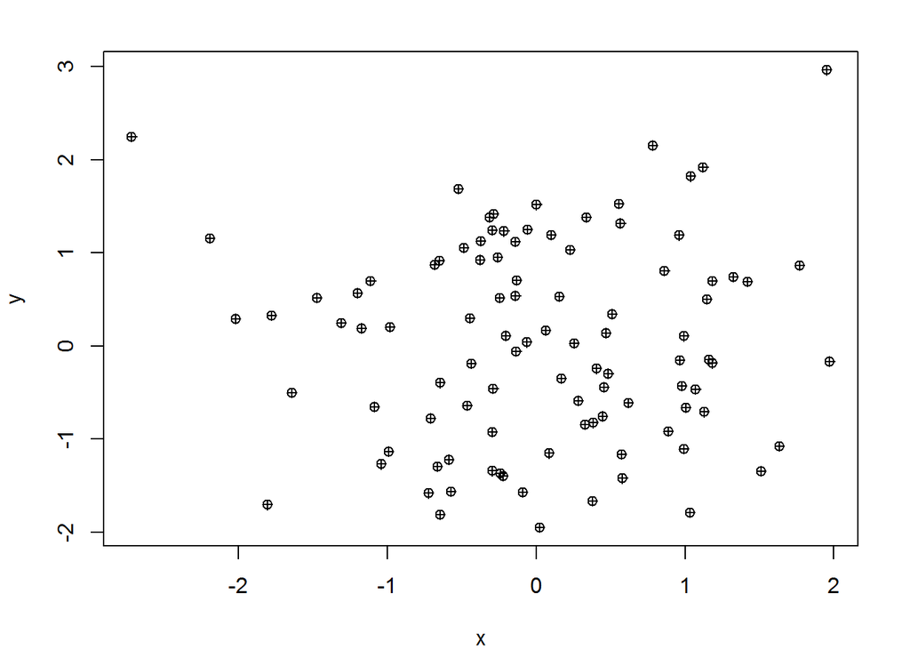

```r
par(mar = c(4,4,2,2))
plot(x,y, pch = 10)
```

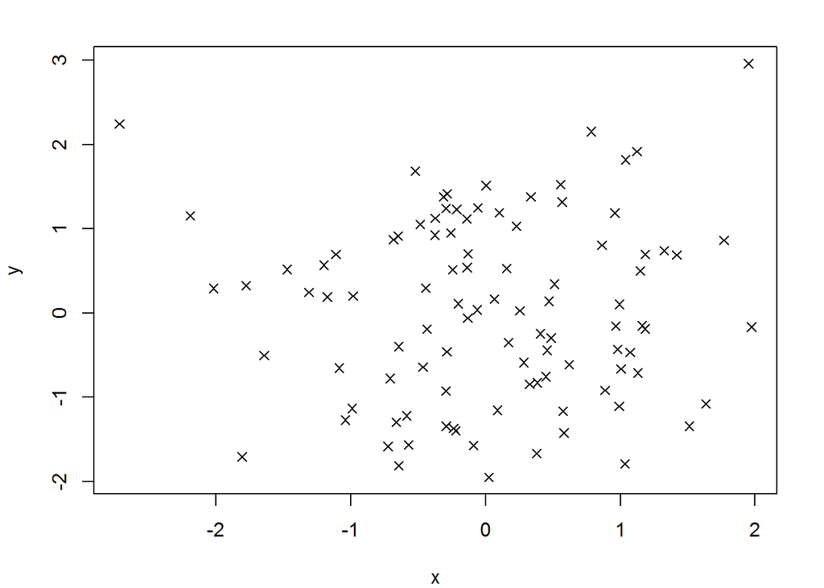

```r
plot(x,y, pch = 4)
```

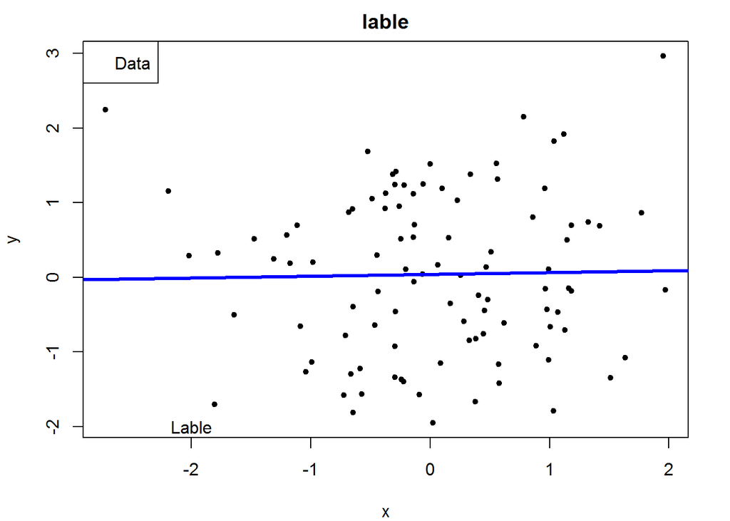

```r
plot(x,y, pch = 20)
title("lable")
text(-2, -2, "Lable")
legend("topleft", legend = "Data")
fit <- lm(y ~ x)
abline(fit)
abline(fit, lwd = 3, col="blue")
```

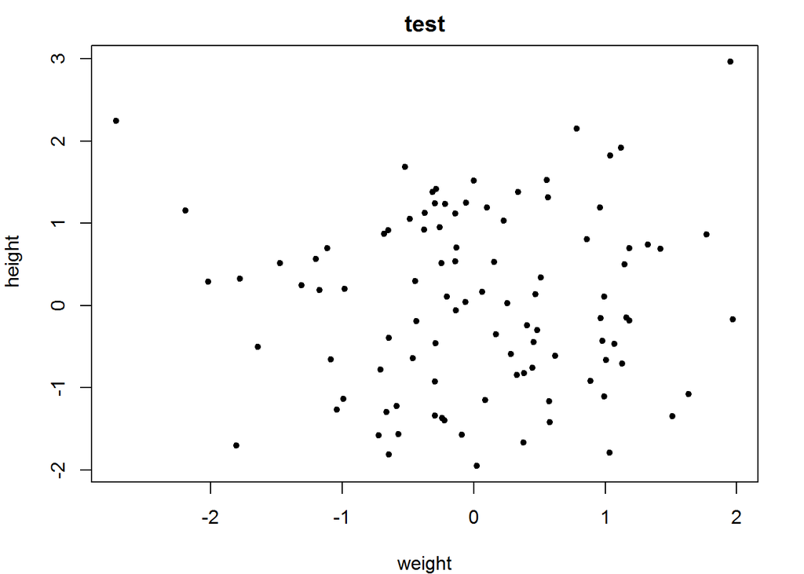

```r
plot(x, y, xlab ="weight", ylab =" height", main = "test", pch = 20)
```

```r
z <- rpois(100, 2)
par(mfrow = c(2,1))
plot(x,y, pch =20)
plot(x,y, pch =19)
par("mar") # 파라미터 확인
```

```
## [1] 4 4 2 2
```

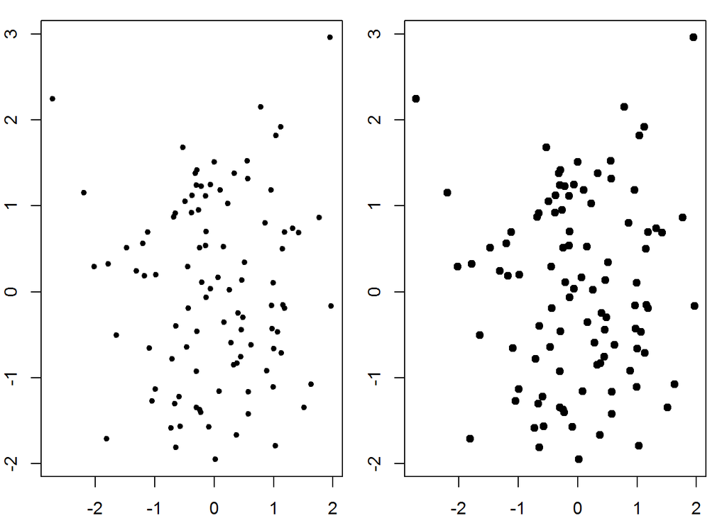

```r
par(mar = c(2,2,1,1))
plot(x,y, pch =20)
plot(x,y, pch =19)
par(mfrow = c(1,2))
plot(x,y, pch =20)
plot(x,y, pch =19)
```

```r
par(mfrow = c(1,1))
y <- x + rnorm(100)
g <- gl(2, 50)
g <- gl(2, 50, labels = c("Male","Female"))
str(g)
```

```
##  Factor w/ 2 levels "Male","Female": 1 1 1 1 1 1 1 1 1 1 ...
```

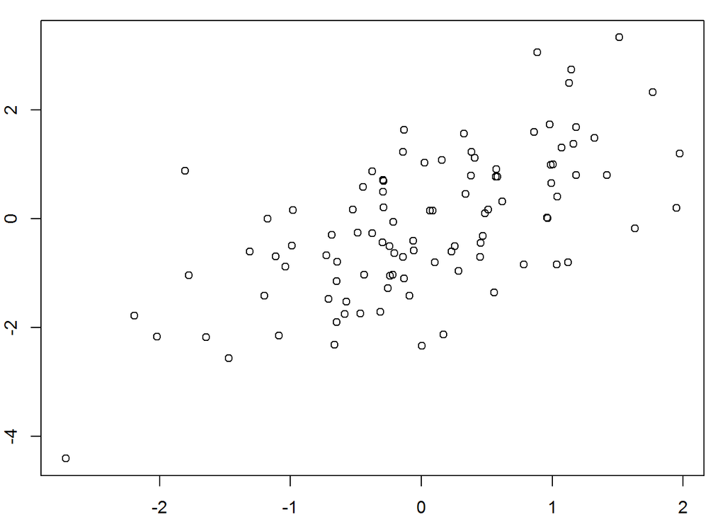

```r
plot(x,y)
```

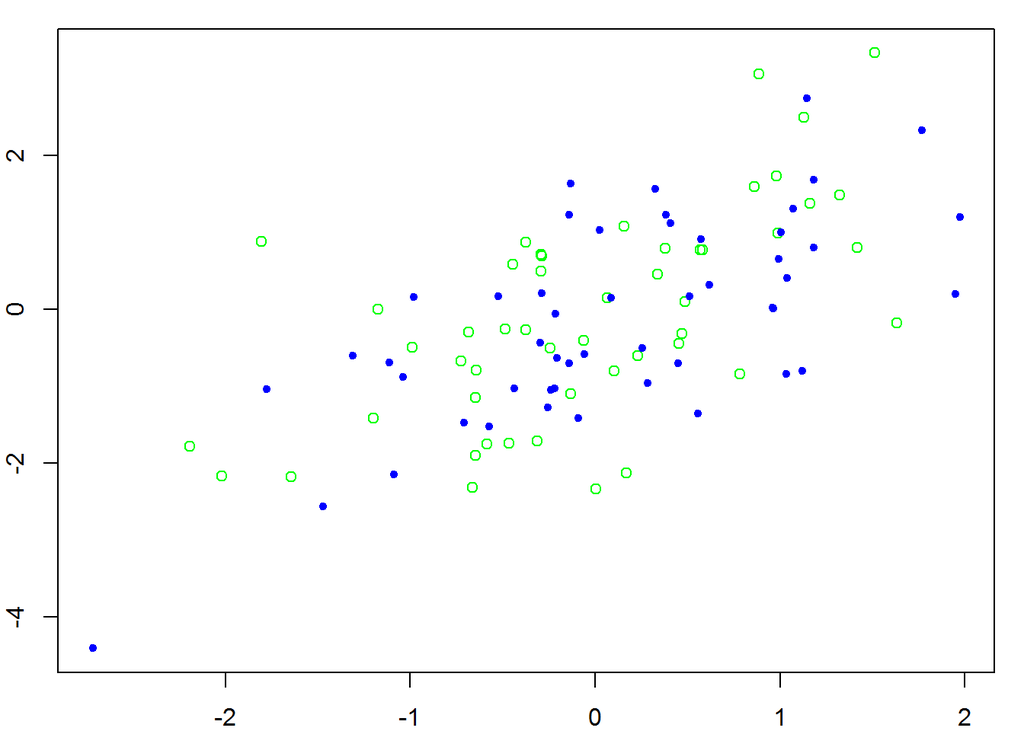

```r
plot(x,y, type = "n")
points(x[g =="Male"], y[g =="Male"], col="green")
points(x[g =="Female"], y[g =="Female"], col="blue", pch = 20)
```

```r
setwd("E:/")
dev.copy(png, file = "test.png") # 차트 이미지 복사.
```

```r
dev.off()
```

## 2. Lattice Plotting System(격자 Plot)

#### lattice : xyplot, bwplot, histogram, stripplot, dotplot, splom, levelplot, contourplot

#### grid xyplot(y ~ x | y * g, data)

```r
#install.packages("lattice")
#library(lattice)
#xyplot(Ozone ~ Wind, data = airquality)
#with(airquality, plot(Wind, Ozone))
#airquality <- transform(airquality, Month =factor(Month))
#xyplot(Ozone ~ Wind | Month , data = airquality, layout = c(5,1))
#p <- xyplot(Ozone ~ Wind, data = airquality)
#print(p) #plot appears
#xyplot(Ozone ~ Wind, data = airquality) #auto-printing
```

## 3. ggplot2 Plot

```r
#install.packages("ggplot2")
#library(ggplot2)
#data(mpg)
#str(mpg)
#qplot(displ, hwy, data = mpg)
```